# **Appendix C:** Data, documentation and analysis scripts for *Accuracy Assessment of Two Electromagnetic Articulographs: NDI WAVE and NDI VOX*

Teja Rebernik (t.rebernik@rug.nl), Jidde Jacobi, Mark Tiede, Martijn Wieling

Generated on 28/01/2021 10:59:23

# 1 Abstract

**Purpose**: This study compares two electromagnetic articulographs (EMA) manufactured by Northern Digital, Inc.: the NDI Wave System (2008) and the NDI Vox-EMA System (2020).

**Method**: Four experiments were completed: (a) comparison of statically positioned sensors; (b) tracking dynamic movements of sensors manipulated using a motor-driven LEGO apparatus; (c) tracking small and large movements of sensors mounted in a rigid bar manipulated by hand; and (d) tracking movements of sensors rotated on a circular disc. We assessed spatial variability for statically positioned sensors, variability in the transduced Euclidean distances (EDs) between sensor pairs, and missing data rates. For sensors tracking circular movements, we compared the fit between fitted ideal circles and actual trajectories.

**Results**: The average sensor pair tracking error (i.e., the standard deviation of the EDs) was 1.37 mm for the WAVE and 0.12 mm for the VOX during automated trials at the fastest speed, and 0.35 mm for the WAVE and 0.14 mm for the VOX during the tracking of large manual movements. The average standard deviation of the fitted circle radii charted by manual circular disc movements was 0.72 mm for the WAVE sensors and 0.14 mm for the VOX sensors. There was no significant difference between the WAVE and the VOX in the number of missing frames.

**Conclusions**: In general, the VOX system significantly outperformed the WAVE on measures of both static precision and dynamic accuracy (automated and manual). For both systems, positional precision and spatial variability were influenced by the sensors’ position relative to the field generator unit (FGU; worse when further away).

# 2 Libraries and functions

```r
# load required packages
library(mgcv)
packageVersion("mgcv")
```

```
## [1] '1.8.33'
```

```r
library(itsadug)
packageVersion("itsadug")
```

```
## [1] '2.4'
```

```r
library(beanplot)
packageVersion("beanplot")
```

```
## [1] '1.2'
```

```r
# R version information
R.version.string
```

```
## [1] "R version 4.0.2 (2020-06-22)"
```

# 3 Static trials

## 3.1 Dataset

```r
tab2 <- read.csv("static-coordinates.csv")

tab2$articulograph = as.factor(tab2$articulograph)
tab2$position = as.factor(tab2$position)
tab2$trial = as.factor(tab2$trial)
tab2$sensorpos = as.factor(tab2$sensor)
tab2$sensorset = (tab2$trial %in% c('t1','t2'))
tab2$sensorset = paste(tab2$sensorpos,tab2$sensorset,sep='')
tab2$sensorset = as.factor(tab2$sensorset)

tab2$sensor = interaction(tab2$articulograph,tab2$sensorpos)
tab2$coordinate = as.factor(tab2$coordinate)
levels(tab2$coordinate) = c('Pitch', 'X','Y','Z','Yaw')
tab2 = droplevels(tab2[tab2$position != 'p16',]) # remove p16 as it was not used in our data analysis
```

```r
str(tab2)
```

```
## 'data.frame':    4800 obs. of  8 variables:
##  $ articulograph: Factor w/ 2 levels "VOX","WAVE": 2 2 2 2 2 2 2 2 1 1 ...
##  $ position     : Factor w/ 15 levels "p1","p10","p11",..: 1 1 1 1 1 1 1 1 1 1 ...
##  $ trial        : Factor w/ 4 levels "t1","t2","t3",..: 1 1 1 1 1 1 1 1 1 1 ...
##  $ sensor       : Factor w/ 16 levels "VOX.s1","WAVE.s1",..: 2 4 6 8 10 12 14 16 1 3 ...
##  $ coordinate   : Factor w/ 5 levels "Pitch","X","Y",..: 2 2 2 2 2 2 2 2 2 2 ...
##  $ SD           : num  0.0151 0.0261 0.0104 0.0051 0.0084 0.0133 0.0604 0.0374 0.0345 0.0031 ...
##  $ sensorpos    : Factor w/ 8 levels "s1","s2","s3",..: 1 2 3 4 5 6 7 8 1 2 ...
##  $ sensorset    : Factor w/ 16 levels "s1FALSE","s1TRUE",..: 2 4 6 8 10 12 14 16 2 4 ...
```

```r
head(tab2)
```

```
##   articulograph position trial  sensor coordinate     SD sensorpos sensorset
## 1          WAVE       p1    t1 WAVE.s1          X 0.0151        s1    s1TRUE
## 2          WAVE       p1    t1 WAVE.s2          X 0.0261        s2    s2TRUE
## 3          WAVE       p1    t1 WAVE.s3          X 0.0104        s3    s3TRUE
## 4          WAVE       p1    t1 WAVE.s4          X 0.0051        s4    s4TRUE
## 5          WAVE       p1    t1 WAVE.s5          X 0.0084        s5    s5TRUE
## 6          WAVE       p1    t1 WAVE.s6          X 0.0133        s6    s6TRUE
```

## 3.2 Trial variability

We compared the four trials to see if there is a difference between them. All trials show similar patterns, which led us to averaging our results in the tables found in the paper.

```r
# there is no differential effect of trial
summary(m<-gam(SD+1e-04 ~ trial*articulograph+ s(sensorset,articulograph,bs='re'), data = tab2[tab2$coordinate %in% c('X','Y','Z','Pitch','Yaw'),],method='REML',family=Gamma(link=log)))
```

```
##
## Family: Gamma
## Link function: log
##
## Formula:
## SD + 1e-04 ~ trial * articulograph + s(sensorset, articulograph,
##     bs = "re")
##
## Parametric coefficients:
##                            Estimate Std. Error t value Pr(>|t|)
## (Intercept)               -3.512776   0.477279  -7.360 2.15e-13 ***
## trialt2                   -0.013647   0.136130  -0.100   0.9202
## trialt3                   -0.225549   0.674974  -0.334   0.7383
## trialt4                   -0.228505   0.674974  -0.339   0.7350
## articulographWAVE          1.535972   0.674974   2.276   0.0229 *
## trialt2:articulographWAVE  0.003894   0.192517   0.020   0.9839
## trialt3:articulographWAVE  0.388446   0.954558   0.407   0.6841
## trialt4:articulographWAVE  0.411314   0.954558   0.431   0.6666
## ---
## Signif. codes:  0 '***' 0.001 '**' 0.01 '*' 0.05 '.' 0.1 ' ' 1
##
## Approximate significance of smooth terms:
##                              edf Ref.df     F p-value
## s(sensorset,articulograph) 27.42     28 16.49  <2e-16 ***
## ---
## Signif. codes:  0 '***' 0.001 '**' 0.01 '*' 0.05 '.' 0.1 ' ' 1
##
## R-sq.(adj) =  0.00906   Deviance explained = 43.3%
## -REML = -9293.9  Scale est. = 5.5594    n = 4800
```

Which is also clear from the visualization:

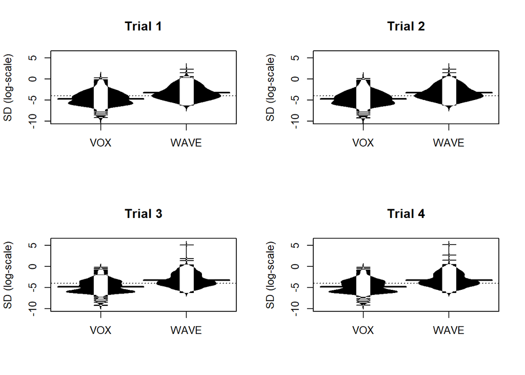

```r
par(mfrow=c(2,2)) # note that for the visualization a small value is added as taking the logarithm of 0 is not possible
beanplot(log(SD+1e-04)~articulograph,data=tab2[tab2$trial=='t1',],bw='bcv',ylab='SD (log-scale)',log='',method='jitter',main='Trial 1',ylim=c(-10,6))
beanplot(log(SD+1e-04)~articulograph,data=tab2[tab2$trial=='t2',],bw='bcv',ylab='SD (log-scale)',log='',method='jitter',main='Trial 2',ylim=c(-10,6))
beanplot(log(SD+1e-04)~articulograph,data=tab2[tab2$trial=='t3',],bw='bcv',ylab='SD (log-scale)',log='',method='jitter',main='Trial 3',ylim=c(-10,6))
beanplot(log(SD+1e-04)~articulograph,data=tab2[tab2$trial=='t4',],bw='bcv',ylab='SD (log-scale)',log='',method='jitter',main='Trial 4',ylim=c(-10,6))
```

## 3.3 Static precision comparison

This part assesses the static precision of the WAVE and the VOX. It corresponds to Table 2 and Figure 10 in the paper.

### 3.3.1 GAM model

We assessed the static precision of the VOX and the WAVE. The VOX was significantly better (p < 0.001)

```r
# Gamma model due to non-Gaussian distribution of residuals (due to large outliers of Wave)
summary(m<-gam(SD+1e-04 ~ articulograph+ s(sensorset,articulograph,bs='re'), data = tab2[tab2$coordinate %in% c('X','Y','Z','Pitch','Yaw'),],method='REML',family=Gamma(link=log)))
```

```
##
## Family: Gamma
## Link function: log
##
## Formula:
## SD + 1e-04 ~ articulograph + s(sensorset, articulograph, bs = "re")
##
## Parametric coefficients:
##                   Estimate Std. Error t value Pr(>|t|)
## (Intercept)        -3.6297     0.3262 -11.129  < 2e-16 ***
## articulographWAVE   1.7369     0.4613   3.766 0.000168 ***
## ---
## Signif. codes:  0 '***' 0.001 '**' 0.01 '*' 0.05 '.' 0.1 ' ' 1
##
## Approximate significance of smooth terms:
##                              edf Ref.df     F p-value
## s(sensorset,articulograph) 29.35     30 15.63  <2e-16 ***
## ---
## Signif. codes:  0 '***' 0.001 '**' 0.01 '*' 0.05 '.' 0.1 ' ' 1
##
## R-sq.(adj) =  0.00989   Deviance explained = 43.3%
## -REML =  -9300  Scale est. = 5.5724    n = 4800
```

```r
# Quantification of the effect on the measurement scale
summary(m<-gam(SD ~ articulograph + s(sensorset,articulograph,bs='re'), data = tab2[tab2$coordinate %in% c('X','Y','Z','Pitch','Yaw')&tab2$SD < 100,],method='REML'))
```

```
##
## Family: gaussian
## Link function: identity
##
## Formula:
## SD ~ articulograph + s(sensorset, articulograph, bs = "re")
##
## Parametric coefficients:
##                   Estimate Std. Error t value Pr(>|t|)
## (Intercept)        0.03277    0.01499   2.186   0.0289 *
## articulographWAVE  0.11541    0.02120   5.443 5.51e-08 ***
## ---
## Signif. codes:  0 '***' 0.001 '**' 0.01 '*' 0.05 '.' 0.1 ' ' 1
##
## Approximate significance of smooth terms:
##                              edf Ref.df     F p-value
## s(sensorset,articulograph) 22.69     30 3.095  <2e-16 ***
## ---
## Signif. codes:  0 '***' 0.001 '**' 0.01 '*' 0.05 '.' 0.1 ' ' 1
##
## R-sq.(adj) =  0.0426   Deviance explained = 4.73%
## -REML = 1967.2  Scale est. = 0.13139   n = 4798
```

### 3.3.2 Visualization

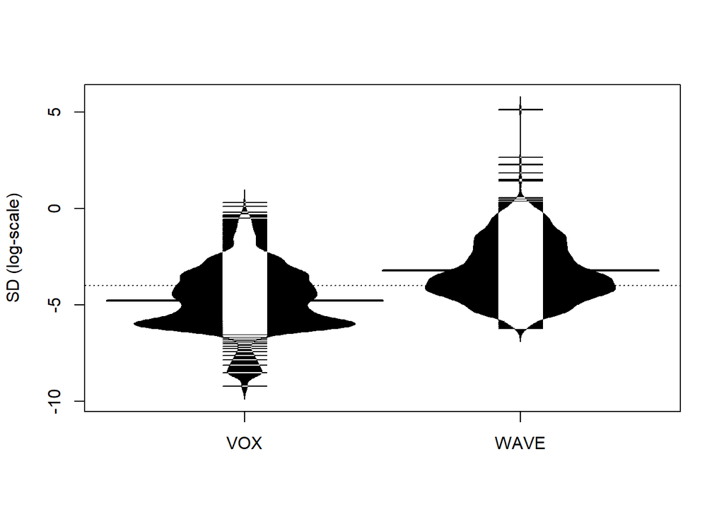

```r
# Figure 10 in paper
par(mfrow=c(1,1))
beanplot(log(SD+1e-04)~articulograph,data=tab2[tab2$coordinate %in% c('X','Y','Z','Pitch','Yaw'),],bw='bcv',main='',ylab='SD (log-scale)',log='',method='jitter')
```

## 3.4 Effect of FGU distance

This part assesses the effect of actual distance from FGU (along the z-axis) on the SDs.

```r
# Defining the distance from the FGU for each position (movement along the z-axis)
tab2$distance = NA
tab2[tab2$position=='p1',]$distance = 9
tab2[tab2$position=='p2',]$distance = 13
tab2[tab2$position=='p3',]$distance = 17.8
tab2[tab2$position=='p4',]$distance = 22.6
tab2[tab2$position=='p5',]$distance = 27.4
tab2[tab2$position=='p6',]$distance = 33.8
tab2p = droplevels(tab2[tab2$position %in% c('p1','p2','p3','p4','p5','p6'),])
```

### 3.4.1 GAM model

We assessed the effect of distance on the static precision. Both articulographs were less accurate when sensors were further away from the FGU.

```r
summary(m<-bam(SD+1e-4 ~ s(distance,by=articulograph,k=6) + articulograph + s(distance,sensorset,by=articulograph, bs='fs',m=1,k=6), data = tab2p,method='fREML',family=Gamma(link=log), discrete=T))
```

```
##
## Family: Gamma
## Link function: log
##
## Formula:
## SD + 1e-04 ~ s(distance, by = articulograph, k = 6) + articulograph +
##     s(distance, sensorset, by = articulograph, bs = "fs", m = 1,
##         k = 6)
##
## Parametric coefficients:
##                   Estimate Std. Error t value Pr(>|t|)
## (Intercept)        -3.7112     0.2152 -17.243  < 2e-16 ***
## articulographWAVE   1.3561     0.2216   6.119 1.15e-09 ***
## ---
## Signif. codes:  0 '***' 0.001 '**' 0.01 '*' 0.05 '.' 0.1 ' ' 1
##
## Approximate significance of smooth terms:
##                                            edf Ref.df        F  p-value
## s(distance):articulographVOX             2.855    3.3   52.506  < 2e-16 ***
## s(distance):articulographWAVE            1.000    1.0 1286.060  < 2e-16 ***
## s(distance,sensorset):articulographVOX  45.850   94.0    6.656  < 2e-16 ***
## s(distance,sensorset):articulographWAVE  9.521   94.0    0.277 0.000348 ***
## ---
## Signif. codes:  0 '***' 0.001 '**' 0.01 '*' 0.05 '.' 0.1 ' ' 1
##
## R-sq.(adj) =  0.538   Deviance explained = 63.6%
## fREML = 2784.4  Scale est. = 0.98052   n = 1920
```

### 3.4.2 GAM model: WAVE vs. VOX

We additionally assessed statistically whether the WAVE is more affected by distance than the VOX. The results show the WAVE is affected more than the VOX (significantly). This is visualized in Figure 11 in the paper.

```r
tab2p$articulographO = as.ordered(tab2p$articulograph)
contrasts(tab2p$articulographO) = 'contr.treatment'

summary(m<-bam(SD+1e-4 ~ s(distance,k=6) + s(distance,by=articulographO,k=6) + articulographO + s(distance,sensorset,by=articulograph, bs='fs',m=1,k=6), data = tab2p,method='fREML',family=Gamma(link=log), discrete=T))
```

```
##
## Family: Gamma
## Link function: log
##
## Formula:
## SD + 1e-04 ~ s(distance, k = 6) + s(distance, by = articulographO,
##     k = 6) + articulographO + s(distance, sensorset, by = articulograph,
##     bs = "fs", m = 1, k = 6)
##
## Parametric coefficients:
##                    Estimate Std. Error t value Pr(>|t|)
## (Intercept)         -3.6774     0.2143 -17.159  < 2e-16 ***
## articulographOWAVE   1.3455     0.2208   6.093 1.34e-09 ***
## ---
## Signif. codes:  0 '***' 0.001 '**' 0.01 '*' 0.05 '.' 0.1 ' ' 1
##
## Approximate significance of smooth terms:
##                                            edf Ref.df      F  p-value
## s(distance)                              3.187  3.757 46.561  < 2e-16 ***
## s(distance):articulographOWAVE           1.000  1.000 11.619 0.000667 ***
## s(distance,sensorset):articulographVOX  46.310 94.000  6.701  < 2e-16 ***
## s(distance,sensorset):articulographWAVE  9.593 94.000  0.283 0.000289 ***
## ---
## Signif. codes:  0 '***' 0.001 '**' 0.01 '*' 0.05 '.' 0.1 ' ' 1
##
## R-sq.(adj) =  0.539   Deviance explained = 63.6%
## fREML =   2784  Scale est. = 0.97754   n = 1920
```

```r
# As s(distance):articulographOWAVE has 1 edf, it is linear, so we fit a linear interaction directly to assess the direction of the effect
summary(m<-gam(SD+1e-4 ~ articulograph*distance + s(sensorset,articulograph,bs='re') + s(sensorset,distance,bs='re'), data = tab2p,method='REML',family=Gamma(link=log)))
```

```
##
## Family: Gamma
## Link function: log
##
## Formula:
## SD + 1e-04 ~ articulograph * distance + s(sensorset, articulograph,
##     bs = "re") + s(sensorset, distance, bs = "re")
##
## Parametric coefficients:
##                             Estimate Std. Error t value Pr(>|t|)
## (Intercept)                -5.815512   0.270890 -21.468  < 2e-16 ***
## articulographWAVE           0.609554   0.383096   1.591    0.112
## distance                    0.103157   0.007066  14.600  < 2e-16 ***
## articulographWAVE:distance  0.033707   0.006060   5.562 3.05e-08 ***
## ---
## Signif. codes:  0 '***' 0.001 '**' 0.01 '*' 0.05 '.' 0.1 ' ' 1
##
## Approximate significance of smooth terms:
##                              edf Ref.df     F  p-value
## s(sensorset,articulograph) 28.17     30 520.4  < 2e-16 ***
## s(sensorset,distance)      11.90     15 594.2 7.06e-06 ***
## ---
## Signif. codes:  0 '***' 0.001 '**' 0.01 '*' 0.05 '.' 0.1 ' ' 1
##
## R-sq.(adj) =  0.528   Deviance explained =   62%
## -REML = -3818.3  Scale est. = 1.2477    n = 1920
```

### 3.4.3 Visualization

```r
# Figure 11 in paper
tab2p = droplevels(tab2[tab2$position %in% c('p1','p2','p3','p4','p5','p6'),])
levels(tab2p$position) = c('1','2','3','4','5','6')

summary(m<-bam(SD+1e-4 ~ s(distance,by=articulograph,k=6) + articulograph + s(distance,sensorset,by=articulograph, bs='fs',m=1,k=6), data = tab2p,method='fREML',family=Gamma(link=log), discrete=T))
```

```
##
## Family: Gamma
## Link function: log
##
## Formula:
## SD + 1e-04 ~ s(distance, by = articulograph, k = 6) + articulograph +
##     s(distance, sensorset, by = articulograph, bs = "fs", m = 1,
##         k = 6)
##
## Parametric coefficients:
##                   Estimate Std. Error t value Pr(>|t|)
## (Intercept)        -3.7112     0.2152 -17.243  < 2e-16 ***
## articulographWAVE   1.3561     0.2216   6.119 1.15e-09 ***
## ---
## Signif. codes:  0 '***' 0.001 '**' 0.01 '*' 0.05 '.' 0.1 ' ' 1
##
## Approximate significance of smooth terms:
##                                            edf Ref.df        F  p-value
## s(distance):articulographVOX             2.855    3.3   52.506  < 2e-16 ***
## s(distance):articulographWAVE            1.000    1.0 1286.060  < 2e-16 ***
## s(distance,sensorset):articulographVOX  45.850   94.0    6.656  < 2e-16 ***
## s(distance,sensorset):articulographWAVE  9.521   94.0    0.277 0.000348 ***
## ---
## Signif. codes:  0 '***' 0.001 '**' 0.01 '*' 0.05 '.' 0.1 ' ' 1
##
## R-sq.(adj) =  0.538   Deviance explained = 63.6%
## fREML = 2784.4  Scale est. = 0.98052   n = 1920
```

```r
par(mfrow=c(1,3))
plot_smooth(m,view='distance',plot_all='articulograph', shade=T,ylab='SD (log-scale)',xlab='Distance from FGU',rug=F, col=c('black','darkgray'), rm.ranef=T)
```

```
## Summary:
##  * articulograph : factor; set to the value(s): VOX, WAVE.
##  * distance : numeric predictor; with 30 values ranging from 9.000000 to 33.800000.
##  * sensorset : factor; set to the value(s): s1FALSE. (Might be canceled as random effect, check below.)
##  * NOTE : The following random effects columns are canceled: s(distance,sensorset):articulographVOX,s(distance,sensorset):articulographWAVE
##
```

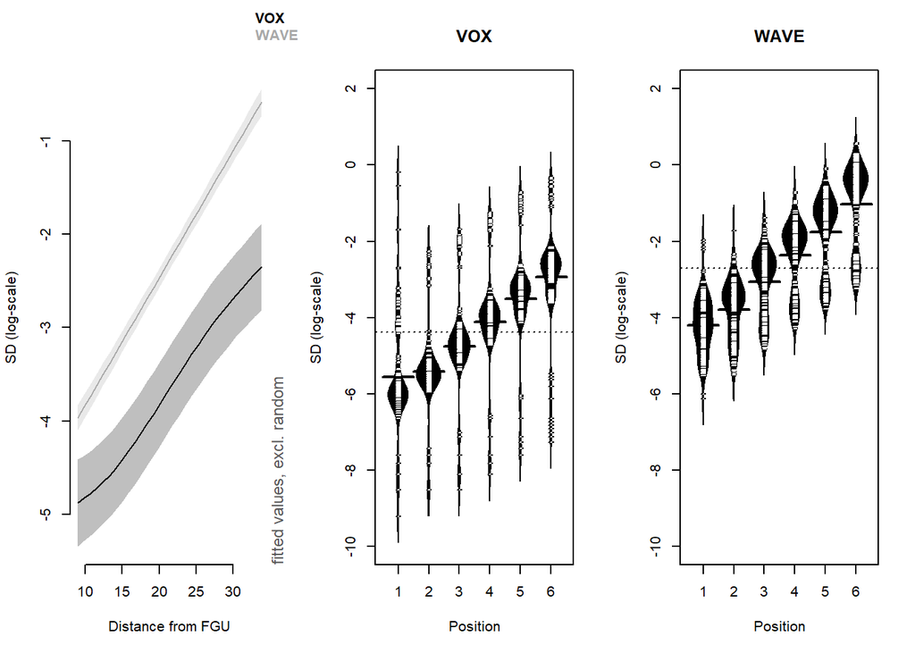

```r
beanplot(log(SD+1e-04)~position,data=tab2p[tab2p$articulograph=='VOX',],bw='bcv',ylab='SD (log-scale)',log='',method='jitter',main='VOX',ylim=c(-10,2),xlab='Position')
beanplot(log(SD+1e-04)~position,data=tab2p[tab2p$articulograph=='WAVE',],bw='bcv',ylab='SD (log-scale)',log='',method='jitter',main='WAVE',ylim=c(-10,2),xlab='Position')
```

## 3.5 Distance measurements

This part assesses the error between the actual (hand-measured) distance and the distance determined using the reported sensor coordinates. It corresponds to Table 3 and Figure 12 in the paper. The VOX and the WAVE do not significantly differ regarding the inferred distances (p = 0.5)

### 3.5.1 Dataset

```r
tab3 <- read.csv("distance-measures.csv")
tab3$articulograph = as.factor(tab3$articulograph)
tab3$trial = as.factor(tab3$trial)
tab3$sensor = as.factor(tab3$sensor)
tab3$sensorSet = as.factor(tab3$sensorSet)
tab3$sens = interaction(tab3$sensor,tab3$sensorSet)
tab3$positionPair = as.factor(tab3$positionPair)
```

```r
str(tab3)
```

```
## 'data.frame':    176 obs. of  7 variables:
##  $ articulograph: Factor w/ 2 levels "VOX","WAVE": 2 2 2 2 2 2 2 2 2 2 ...
##  $ trial        : Factor w/ 4 levels "t1","t2","t3",..: 1 1 1 1 1 1 1 1 1 1 ...
##  $ sensor       : Factor w/ 2 levels "s1","s2": 1 1 1 1 1 1 1 1 1 1 ...
##  $ sensorSet    : Factor w/ 4 levels "sv1","sv2","sw1",..: 3 3 3 3 3 3 3 3 3 3 ...
##  $ positionPair : Factor w/ 11 levels "eightnine","eleventwelve",..: 6 11 10 4 3 7 1 8 2 9 ...
##  $ error        : num  0.065 0.279 0.521 0.732 1.158 ...
##  $ sens         : Factor w/ 8 levels "s1.sv1","s2.sv1",..: 5 5 5 5 5 5 5 5 5 5 ...
```

```r
head(tab3)
```

```
##   articulograph trial sensor sensorSet positionPair  error   sens
## 1          WAVE    t1     s1       sw1       onetwo 0.0650 s1.sw1
## 2          WAVE    t1     s1       sw1     twothree 0.2786 s1.sw1
## 3          WAVE    t1     s1       sw1    threefour 0.5211 s1.sw1
## 4          WAVE    t1     s1       sw1     fourfive 0.7316 s1.sw1
## 5          WAVE    t1     s1       sw1      fivesix 1.1579 s1.sw1
## 6          WAVE    t1     s1       sw1   seveneight 1.0948 s1.sw1
```

### 3.5.2 GAM model

```r
# Gamma-distributed model with log-link: not significant
summary(m<-gam(error ~ articulograph + s(sens,articulograph,bs='re') + s(positionPair,articulograph,bs='re'), data = tab3,method='REML',family=Gamma(link=log)))
```

```
##
## Family: Gamma
## Link function: log
##
## Formula:
## error ~ articulograph + s(sens, articulograph, bs = "re") + s(positionPair,
##     articulograph, bs = "re")
##
## Parametric coefficients:
##                   Estimate Std. Error t value Pr(>|t|)
## (Intercept)        -1.7289     0.2701  -6.401 1.84e-09 ***
## articulographWAVE   0.2630     0.3820   0.689    0.492
## ---
## Signif. codes:  0 '***' 0.001 '**' 0.01 '*' 0.05 '.' 0.1 ' ' 1
##
## Approximate significance of smooth terms:
##                                  edf Ref.df      F  p-value
## s(sens,articulograph)          4.246      6  3.549 0.000103 ***
## s(positionPair,articulograph) 18.844     20 24.619  < 2e-16 ***
## ---
## Signif. codes:  0 '***' 0.001 '**' 0.01 '*' 0.05 '.' 0.1 ' ' 1
##
## R-sq.(adj) =  0.709   Deviance explained = 70.7%
## -REML = -85.986  Scale est. = 0.32557   n = 176
```

```r
# Gaussian model (using the original measurement scale): also not significant
summary(m<-gam(error ~ articulograph + s(sens,articulograph,bs='re') + s(positionPair,articulograph,bs='re'), data = tab3,method='REML'))
```

```
##
## Family: gaussian
## Link function: identity
##
## Formula:
## error ~ articulograph + s(sens, articulograph, bs = "re") + s(positionPair,
##     articulograph, bs = "re")
##
## Parametric coefficients:
##                   Estimate Std. Error t value Pr(>|t|)
## (Intercept)         0.2332     0.1426   1.635    0.104
## articulographWAVE   0.2391     0.2017   1.185    0.238
##
## Approximate significance of smooth terms:
##                                  edf Ref.df      F  p-value
## s(sens,articulograph)          4.984      6  4.907 1.51e-05 ***
## s(positionPair,articulograph) 18.923     20 17.577  < 2e-16 ***
## ---
## Signif. codes:  0 '***' 0.001 '**' 0.01 '*' 0.05 '.' 0.1 ' ' 1
##
## R-sq.(adj) =  0.702   Deviance explained = 74.5%
## -REML = 62.003  Scale est. = 0.076248  n = 176
```

### 3.5.3 Visualization

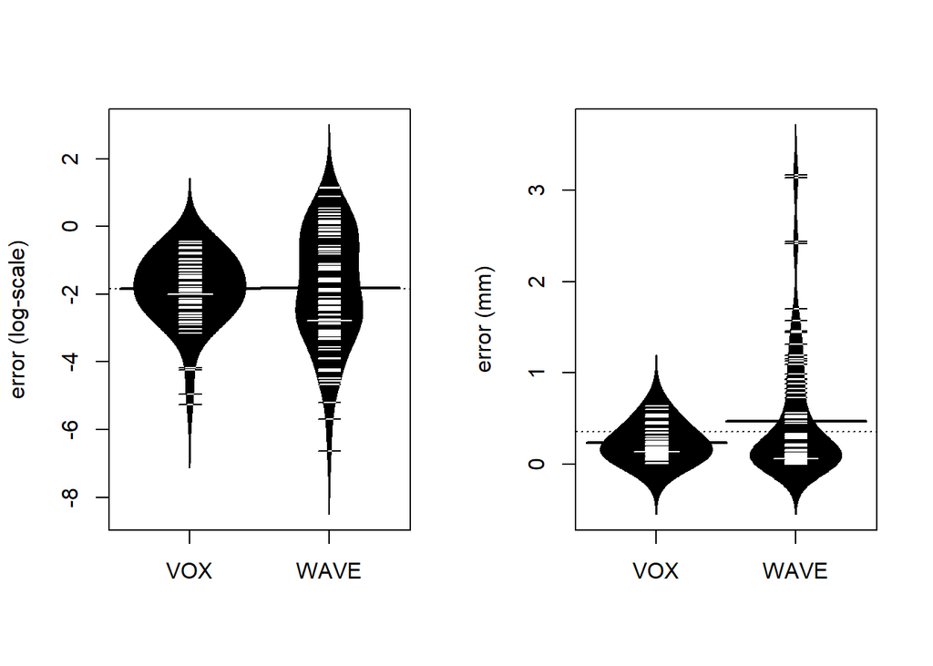

```r
# Figure 12 in paper

par(mfrow=c(1,2)); beanplot(log(error)~articulograph,data=tab3,bw='bcv',main='',ylab='error (log-scale)',log='')
beanplot(error~articulograph,data=tab3,bw='bcv',main='',ylab='error (mm)',log='')
```

# 4 Dynamic trials

This part assesses dynamic accuracy during automated dynamic trials. It corresponds to Table 4 and Figures 17 and 18 in the paper.

## 4.1 Dataset

```r
datAut <- read.csv("vox-wave-automatic.csv")

datAut$articulograph <- as.factor(datAut$articulograph)
levels(datAut$articulograph) = c('VOX','WAVE') # capitalize levels
datAut$rigidBody <- as.factor(datAut$rigidBody)
datAut$trial <- as.factor(datAut$trial)
datAut$sensorSet <- as.factor(datAut$sensorSet)
```

```r
str(datAut)
```

```
## 'data.frame':    160 obs. of  6 variables:
##  $ articulograph: Factor w/ 2 levels "VOX","WAVE": 2 2 2 2 2 2 2 2 2 2 ...
##  $ rigidBody    : Factor w/ 5 levels "circle","eccentricLarge",..: 1 1 1 1 3 3 3 3 2 2 ...
##  $ speed        : int  0 1 2 3 0 1 2 3 0 1 ...
##  $ trial        : Factor w/ 4 levels "t1","t2","t3",..: 1 1 1 1 1 1 1 1 1 1 ...
##  $ sensorSet    : Factor w/ 4 levels "v1","v2","w1",..: 3 3 3 3 3 3 3 3 3 3 ...
##  $ SD           : num  0.76 3.74 5.16 6.27 0.09 0.23 0.33 0.44 0.03 0.09 ...
```

```r
head(datAut)
```

```
##   articulograph      rigidBody speed trial sensorSet   SD
## 1          WAVE         circle     0    t1        w1 0.76
## 2          WAVE         circle     1    t1        w1 3.74
## 3          WAVE         circle     2    t1        w1 5.16
## 4          WAVE         circle     3    t1        w1 6.27
## 5          WAVE eccentricSmall     0    t1        w1 0.09
## 6          WAVE eccentricSmall     1    t1        w1 0.23
```

## 4.2 GAM model

Here we assess the articulographs’ accuracy during dynamic trials. Only automated data is used, as the manual dynamic movements are likely not consistent across trials and articulographs. The circularly rotating bar showed the largest standard deviations.

```r
summary(gam(SD ~ articulograph + s(rigidBody,articulograph,bs='re'), data = datAut,family=Gamma(link=log), method='REML'))
```

```
##
## Family: Gamma
## Link function: log
##
## Formula:
## SD ~ articulograph + s(rigidBody, articulograph, bs = "re")
##
## Parametric coefficients:
##                   Estimate Std. Error t value Pr(>|t|)
## (Intercept)        -2.9420     0.4858  -6.056 1.07e-08 ***
## articulographWAVE   1.6603     0.6870   2.417   0.0169 *
## ---
## Signif. codes:  0 '***' 0.001 '**' 0.01 '*' 0.05 '.' 0.1 ' ' 1
##
## Approximate significance of smooth terms:
##                              edf Ref.df     F p-value
## s(rigidBody,articulograph) 7.856      8 74.21  <2e-16 ***
## ---
## Signif. codes:  0 '***' 0.001 '**' 0.01 '*' 0.05 '.' 0.1 ' ' 1
##
## R-sq.(adj) =  0.702   Deviance explained = 85.2%
## -REML = -179.75  Scale est. = 0.33917   n = 160
```

```r
# Quantification of the effect on the measurement scale: non-circle
summary(gam(SD ~ articulograph + s(rigidBody,articulograph,bs='re'), data = datAut[datAut$rigidBody != 'circle',], method='REML')) # normal scale: 0.1 mm difference
```

```
##
## Family: gaussian
## Link function: identity
##
## Formula:
## SD ~ articulograph + s(rigidBody, articulograph, bs = "re")
##
## Parametric coefficients:
##                   Estimate Std. Error t value Pr(>|t|)
## (Intercept)        0.04469    0.02487   1.797  0.07486 .
## articulographWAVE  0.11078    0.03517   3.150  0.00206 **
## ---
## Signif. codes:  0 '***' 0.001 '**' 0.01 '*' 0.05 '.' 0.1 ' ' 1
##
## Approximate significance of smooth terms:
##                              edf Ref.df     F  p-value
## s(rigidBody,articulograph) 5.225      6 6.738 8.18e-07 ***
## ---
## Signif. codes:  0 '***' 0.001 '**' 0.01 '*' 0.05 '.' 0.1 ' ' 1
##
## R-sq.(adj) =  0.478   Deviance explained = 50.3%
## -REML = -143.27  Scale est. = 0.0051156  n = 128
```

```r
# Quantification of the effect on the measurement scale: circle
summary(gam(SD ~ articulograph, data = datAut[datAut$rigidBody == 'circle',], method='REML')) # normal scale for the circle: 3.4 mm difference
```

```
##
## Family: gaussian
## Link function: identity
##
## Formula:
## SD ~ articulograph
##
## Parametric coefficients:
##                   Estimate Std. Error t value Pr(>|t|)
## (Intercept)         0.2025     0.3789   0.534    0.597
## articulographWAVE   3.4256     0.5359   6.392 4.68e-07 ***
## ---
## Signif. codes:  0 '***' 0.001 '**' 0.01 '*' 0.05 '.' 0.1 ' ' 1
##
##
## R-sq.(adj) =  0.563   Deviance explained = 57.7%
## -REML = 57.819  Scale est. = 2.2976    n = 32
```

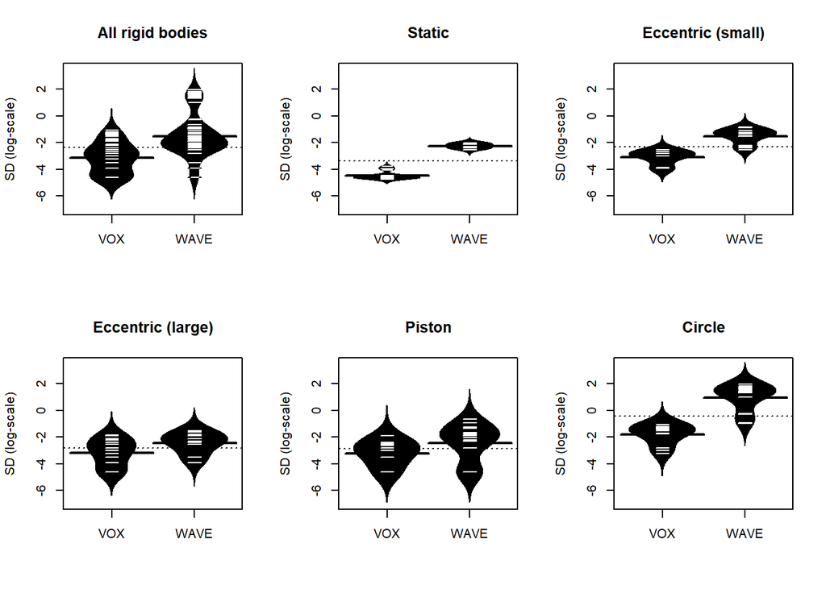

```r
# Figure 17 in paper
par(mfrow=c(2,3))
beanplot(log(SD)~articulograph,data=droplevels(datAut),bw='bcv',main='All rigid bodies',ylab='SD (log-scale)',log='',method='jitter',ylim=c(-7,3.5))
beanplot(log(SD)~articulograph,data=droplevels(datAut[datAut$rigidBody=='static',]),bw='bcv',main='Static',ylab='SD (log-scale)',ylim=c(-7,3.5),method='jitter',log='')
beanplot(log(SD)~articulograph,data=droplevels(datAut[datAut$rigidBody=='eccentricSmall',]),bw='bcv',main='Eccentric (small)',ylab='SD (log-scale)',ylim=c(-7,3.5),method='jitter',log='')
beanplot(log(SD)~articulograph,data=droplevels(datAut[datAut$rigidBody=='eccentricLarge',]),bw='bcv',main='Eccentric (large)',ylab='SD (log-scale)',ylim=c(-7,3.5),method='jitter',log='')
beanplot(log(SD)~articulograph,data=droplevels(datAut[datAut$rigidBody=='piston',]),bw='bcv',main='Piston',ylab='SD (log-scale)',ylim=c(-7,3.5),method='jitter',log='')
beanplot(log(SD)~articulograph,data=droplevels(datAut[datAut$rigidBody=='circle',]),bw='bcv',main='Circle',ylab='SD (log-scale)',ylim=c(-7,3.5),method='jitter',log='')
```

## 4.3 Effect of speed on accuracy

### 4.3.1 GAM model

```r
summary(m<-gam(SD ~  s(speed,by=articulograph,k=4) + articulograph + s(speed,rigidBody,by=articulograph,bs='fs',m=1,k=4), data = datAut,family=Gamma(link=log), method='REML'))
```

```
##
## Family: Gamma
## Link function: log
##
## Formula:
## SD ~ s(speed, by = articulograph, k = 4) + articulograph + s(speed,
##     rigidBody, by = articulograph, bs = "fs", m = 1, k = 4)
##
## Parametric coefficients:
##                   Estimate Std. Error t value Pr(>|t|)
## (Intercept)        -3.1494     0.3769  -8.356 1.12e-13 ***
## articulographWAVE   1.6062     0.7301   2.200   0.0297 *
## ---
## Signif. codes:  0 '***' 0.001 '**' 0.01 '*' 0.05 '.' 0.1 ' ' 1
##
## Approximate significance of smooth terms:
##                                         edf Ref.df      F  p-value
## s(speed):articulographVOX             2.389  2.480  16.84 3.92e-07 ***
## s(speed):articulographWAVE            2.438  2.487  12.09 2.92e-05 ***
## s(speed,rigidBody):articulographVOX  14.304 18.000  60.09  < 2e-16 ***
## s(speed,rigidBody):articulographWAVE 15.312 18.000 140.81  < 2e-16 ***
## ---
## Signif. codes:  0 '***' 0.001 '**' 0.01 '*' 0.05 '.' 0.1 ' ' 1
##
## R-sq.(adj) =  0.968   Deviance explained = 98.5%
## -REML = -306.26  Scale est. = 0.058838  n = 160
```

### 4.3.2 Visualization

```r
# Figure 18 in paper
par(mfrow=c(1,3))
plot_smooth(m,view='speed',plot_all='articulograph', shade=T,ylab='SD (log-scale)',xlab='Movement speed',rug=F, col=c('black','darkgray'), rm.ranef=T)
```

```
## Summary:
##  * articulograph : factor; set to the value(s): VOX, WAVE.
##  * speed : numeric predictor; with 30 values ranging from 0.000000 to 3.000000.
##  * rigidBody : factor; set to the value(s): circle. (Might be canceled as random effect, check below.)
##  * NOTE : The following random effects columns are canceled: s(speed,rigidBody):articulographVOX,s(speed,rigidBody):articulographWAVE
##
```

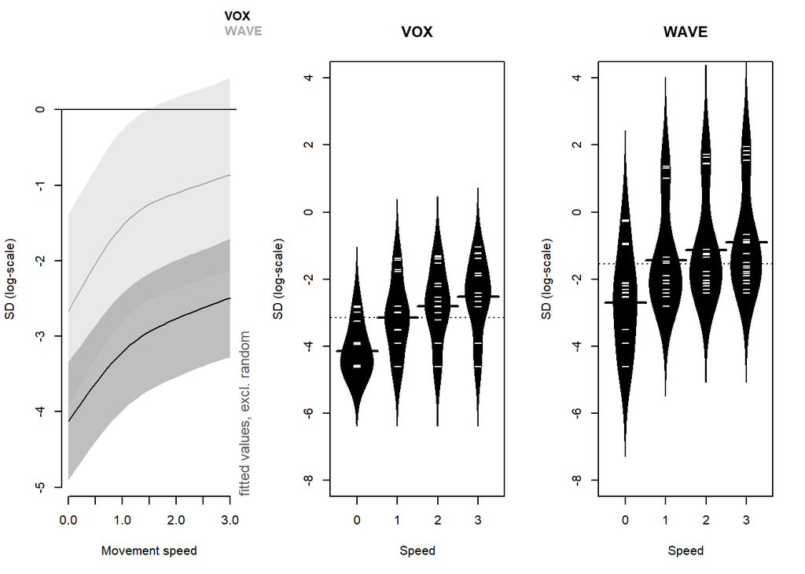

```r
beanplot(log(SD)~speed,data=droplevels(datAut[datAut$articulograph=='VOX',]),bw='bcv',main='VOX',log="",ylab='SD (log-scale)',xlab='Speed',ylim=c(-8,4),method='jitter')
beanplot(log(SD)~speed,data=droplevels(datAut[datAut$articulograph=='WAVE',]),bw='bcv',main='WAVE',log="",ylab='SD (log-scale)',xlab='Speed',ylim=c(-8,4),method='jitter')
```

### 4.3.3 GAM model: WAVE vs. VOX

```r
datAut$articulographO = as.ordered(datAut$articulograph)
contrasts(datAut$articulographO) = 'contr.treatment'
```

```r
summary(m<-gam(SD ~ s(speed,k=4) + s(speed, by=articulographO,k=4) + articulographO + s(speed,rigidBody,by=articulograph,bs='fs',m=1,k=4), data = datAut[datAut$rigidBody!='circle',], method='REML', family=Gamma(link=log))) #when log-transformed, WAVE is not significantly worse than VOX at faster speeds (p = 0.9)
```

```
##
## Family: Gamma
## Link function: log
##
## Formula:
## SD ~ s(speed, k = 4) + s(speed, by = articulographO, k = 4) +
##     articulographO + s(speed, rigidBody, by = articulograph,
##     bs = "fs", m = 1, k = 4)
##
## Parametric coefficients:
##                    Estimate Std. Error t value Pr(>|t|)
## (Intercept)         -3.4679     0.2736 -12.676  < 2e-16 ***
## articulographOWAVE   1.2657     0.3683   3.437 0.000863 ***
## ---
## Signif. codes:  0 '***' 0.001 '**' 0.01 '*' 0.05 '.' 0.1 ' ' 1
##
## Approximate significance of smooth terms:
##                                         edf Ref.df      F  p-value
## s(speed)                              2.409  2.483 13.285 9.55e-06 ***
## s(speed):articulographOWAVE           1.000  1.000  0.012    0.913
## s(speed,rigidBody):articulographVOX  11.199 14.000 30.364  < 2e-16 ***
## s(speed,rigidBody):articulographWAVE 12.420 14.000 25.481  < 2e-16 ***
## ---
## Signif. codes:  0 '***' 0.001 '**' 0.01 '*' 0.05 '.' 0.1 ' ' 1
##
## R-sq.(adj) =   0.84   Deviance explained = 95.2%
## -REML = -308.17  Scale est. = 0.062998  n = 128
```

# 5 Missing data

This part assesses missing data using logistic regression. It corresponds to Table 5 and Figure 19 in the paper.

## 5.1 Dataset

```r
mis <- read.csv("missing-data.csv")
mis$articulograph = as.factor(mis$articulograph)
mis$trial = as.factor(mis$trial)
mis$sensorSet = as.factor(mis$sensorSet)
mis$dynamicTask = as.factor(mis$dynamicTask)
mis$sensor = as.factor(mis$sensor)
mis$sens = interaction(mis$sensor,mis$sensorSet)

mis$missingFrames = round(8000 * mis$missing / 100)
mis$nonMissingFrames = 8000 - mis$missingFrames
```

```r
str(mis)
```

```
## 'data.frame':    360 obs. of  9 variables:
##  $ articulograph   : Factor w/ 2 levels "VOX","WAVE": 2 2 2 2 2 2 2 2 2 2 ...
##  $ trial           : Factor w/ 4 levels "t1","t2","t3",..: 1 1 1 1 1 1 1 1 1 1 ...
##  $ sensorSet       : Factor w/ 8 levels "sv1a","sv1b",..: 5 5 5 5 5 5 5 5 5 5 ...
##  $ dynamicTask     : Factor w/ 6 levels "automatedFast",..: 3 3 3 3 3 3 3 3 2 2 ...
##  $ sensor          : Factor w/ 21 levels "bs1","bs2","bs3",..: 14 15 16 17 18 19 20 21 14 15 ...
##  $ missing         : num  1.6 4.5 0 0 0 0 0 0 6 6 ...
##  $ sens            : Factor w/ 168 levels "bs1.sv1a","bs2.sv1a",..: 98 99 100 101 102 103 104 105 98 99 ...
##  $ missingFrames   : num  128 360 0 0 0 0 0 0 480 480 ...
##  $ nonMissingFrames: num  7872 7640 8000 8000 8000 ...
```

```r
head(mis)
```

```
##   articulograph trial sensorSet   dynamicTask sensor missing     sens
## 1          WAVE    t1      sw1a automatedSlow    sa1     1.6 sa1.sw1a
## 2          WAVE    t1      sw1a automatedSlow    sa2     4.5 sa2.sw1a
## 3          WAVE    t1      sw1a automatedSlow    sa3     0.0 sa3.sw1a
## 4          WAVE    t1      sw1a automatedSlow    sa4     0.0 sa4.sw1a
## 5          WAVE    t1      sw1a automatedSlow    sa5     0.0 sa5.sw1a
## 6          WAVE    t1      sw1a automatedSlow    sa6     0.0 sa6.sw1a
##   missingFrames nonMissingFrames
## 1           128             7872
## 2           360             7640
## 3             0             8000
## 4             0             8000
## 5             0             8000
## 6             0             8000
```

## 5.2 GAM model: WAVE vs. VOX

```r
summary(m<-gam(cbind(missingFrames,nonMissingFrames) ~  articulograph + s(sens,articulograph,bs='re'), data = mis,family=binomial, method='REML'))
```

```
##
## Family: binomial
## Link function: logit
##
## Formula:
## cbind(missingFrames, nonMissingFrames) ~ articulograph + s(sens,
##     articulograph, bs = "re")
##
## Parametric coefficients:
##                   Estimate Std. Error z value Pr(>|z|)
## (Intercept)       -11.3845     0.9245 -12.314   <2e-16 ***
## articulographWAVE   1.7694     1.2564   1.408    0.159
## ---
## Signif. codes:  0 '***' 0.001 '**' 0.01 '*' 0.05 '.' 0.1 ' ' 1
##
## Approximate significance of smooth terms:
##                         edf Ref.df Chi.sq p-value
## s(sens,articulograph) 65.37     82   8325  <2e-16 ***
## ---
## Signif. codes:  0 '***' 0.001 '**' 0.01 '*' 0.05 '.' 0.1 ' ' 1
##
## R-sq.(adj) =  0.674   Deviance explained = 90.8%
## -REML = 3333.7  Scale est. = 1         n = 360
```

### 5.2.1 Visualization

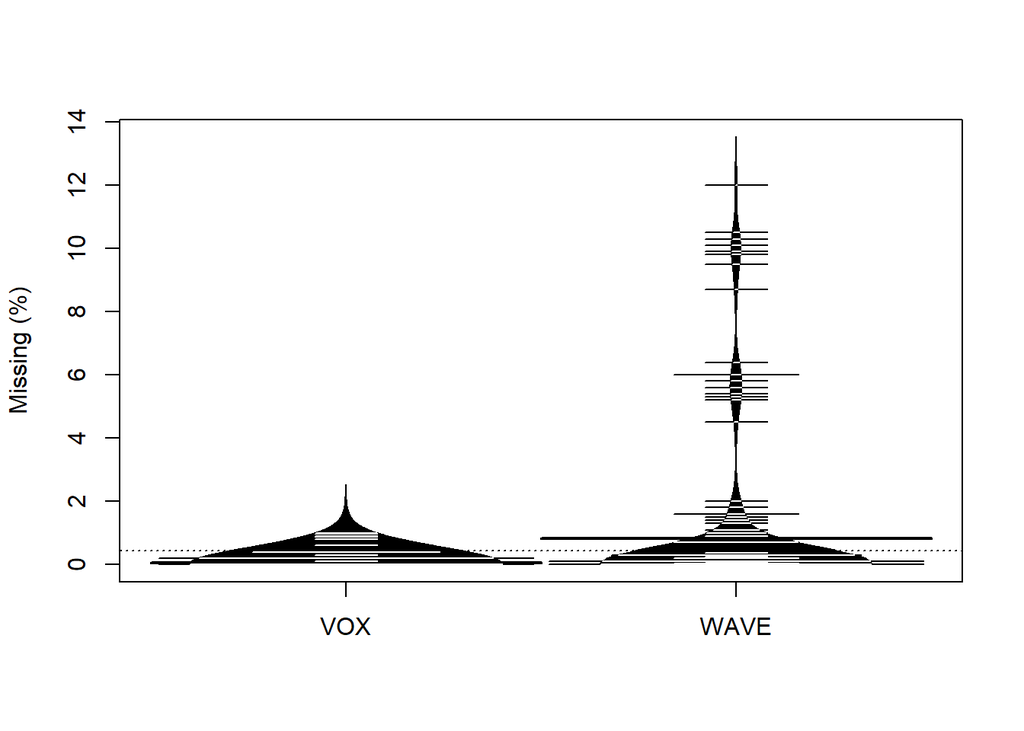

```r
# Figure 19 in paper
par(mfrow=c(1,1))
beanplot(missing~articulograph,data=mis,bw='bcv',log="",ylab='Missing (%)', cutmin = 0)
```

### 5.2.2 Effect of test type

```r
# Assessing whether 'type' (manual vs. automated) plays a role
mis$type = 'Manual'
mis[mis$dynamicTask %in% c('automatedFast', 'automatedMedium','automatedSlow'),]$type = 'Automatic'
mis$type = as.factor(mis$type)
mis$type = relevel(mis$type,'Manual')
```

```r
summary(m<-gam(cbind(missingFrames,nonMissingFrames) ~  articulograph*type + s(sens,articulograph,bs='re'), data = mis,family=binomial, method='REML'))
```

```
##
## Family: binomial
## Link function: logit
##
## Formula:
## cbind(missingFrames, nonMissingFrames) ~ articulograph * type +
##     s(sens, articulograph, bs = "re")
##
## Parametric coefficients:
##                                 Estimate Std. Error z value Pr(>|z|)
## (Intercept)                     -10.1861     1.1041  -9.226   <2e-16 ***
## articulographWAVE                 0.5238     1.5373   0.341   0.7333
## typeAutomatic                    -3.9421     2.3196  -1.700   0.0892 .
## articulographWAVE:typeAutomatic   4.0860     2.9008   1.409   0.1590
## ---
## Signif. codes:  0 '***' 0.001 '**' 0.01 '*' 0.05 '.' 0.1 ' ' 1
##
## Approximate significance of smooth terms:
##                         edf Ref.df Chi.sq p-value
## s(sens,articulograph) 60.65     80   3318  <2e-16 ***
## ---
## Signif. codes:  0 '***' 0.001 '**' 0.01 '*' 0.05 '.' 0.1 ' ' 1
##
## R-sq.(adj) =  0.677   Deviance explained = 90.8%
## -REML = 3325.9  Scale est. = 1         n = 360
```